# Executive Summary

#### This analysis seeks three objectives:

- (1) describe, visualize, and model a complex dataset using supervised machine learning techniques.
- (2) describe, visualize, and segment a complex dataset using unsupervised machine learning techniques.
- (3) extract business insights from applied SQL analysis.

#### **First,** this analysis surveyed the distributions with the following selected findings:

[figure not shown]

- **x1 (independent variable):**
  - *uniform distribution*  
    space
- **x2 (independent variable):**
  - *normal distribution*  
    space
- **x3 (independent variable):**
  - *t-distribution*  
    space
- **x5 (independent variable):**
  - *exponential distribution*  
    space
- **x6 (independent variable):**
  - *binomial distribution*  
    space
- **ya (dependent variable):**
  - *chi2 distribution*  
    space
- **yb (dependent variable):**
  - *reverse log normal distribution*  
    space
- **yc (dependent variable):**
  - *logistic distribution*

#### Regarding predicting the dependent variables, this analysis found the following:

- **For ya:**

[figure not shown]

- **For yb:**

\begin{align} yb = 0.253(x1) + 0.8422 \end{align}

[figure not shown]

- **For yc:**
  - No model appropriate because **yc** does not appear to be related to the independent variables.

#### **Second,** this analysis found through unsupervised machine learning:

- that the unsupervised learning data set could be reduced from 10 dimensions to just **3** (depicted as spheroids below).
  - via a Principal Component Analysis (PCA):
- that the observations could be grouped into **4** cohorts (depicted in hues below).
  - via a K-Means Clustering Analysis:

[figure not shown]

#### **Third,** this analysis derived business insights through SQL:

- such as the following query finding the number of posts in 2017:

[figure not shown]

- such as the following query finding the distribution of views for users:

[figure not shown]

- such as the following query finding the top 10 tags associated with posts created in 2017:

[figure not shown]

- such as the following query finding the average response time in seconds from the time a 2017 question first post to when the official answer is accepted:

[figure not shown]

Credit to God, my Mother, family and friends.

All errors are my own.

Best,  
**George John Jordan Thomas Aquinas Hayward, Optimist**  
**Data Scientist**  
September 30, 2019

- Executive Summary
- Selected Data Visualizations
- **Part I. - Supervised Machine Learning**
  - Question 1 - Part I.A
    - Summary Metric
    - 🔬Function 1: Visualizing & Fitting the Distribution
    - Conclusion: What do now know about the distributions?
  - Question 2 - Part I.B
    - Modeling Gameplan
      - 1. Exploratory Data Analysis
        - Correlation Matrix
        - Pair Plots
        - Using XGBoost & Regressions To See Which Features Seem Important Before Modeling
        - 🔬Function 2: XGBoost Modeler
        - Brief 'Side Path' - Checking for Polynomial Features
      - 2. Modeling
        - 🔬Function 3: Multiple Linear Regression Modeler
        - 🔬Function 4: Single Linear Regression Modeler
    - Conclusion: Equation for Predicting 'ya.'
    - Conclusion: Equation for Predicting 'yb.’
    - Conclusion: No Equation for Predicting 'yc.'
- **Part II. - Unsupervised Machine Learning**
  - Question 3 - Part II.A
    - Summary Metric
    - Correlation Matrix
    - Pair Plots
    - Distributions
  - Question 4 - Part II.B
    - Gameplan for Principal Component Analysis (PCA)
      - 1. Find Number of PCA Components
      - 2. Visualize in Reduced Dimensions
  - Question 5 - Part II.C
    - K-Means Clustering
  - Question 6 - Part II.D - Bonus
- **Part III. - SQL Coding**
  - Question 7 - Part III.A
  - Question 8 - Part III.B
  - Question 9 - Part III.C
  - Question 10 - Part III.D - Bonus
- Thank You!
- #TheLordAlwaysDelivers

# Selected Data Visualizations

#### Surveying the DS1 Distributions

[figure not shown]

#### DS1 Pair Plot

[figure not shown]

#### DS1 Correlation Matrix

[figure not shown]

#### Using XGBoost for 'ya' Feature Selection

[figure not shown]

#### Using XGBoost for 'yb' Feature Selection

[figure not shown]

#### Multiple Linear Regression for 'ya' Prediction

[figure not shown]

#### Simple Linear Regression for 'yb' Prediction

[figure not shown]

#### Selecting Number of Components for DS2 PCA

[figure not shown]

#### 3D-Plotting DS2's K-Means Cohort Results After PCA

[figure not shown]

#### SQL Love-Language Queries

[figure not shown]

Back to Top

## And it begins...

```python
import pandas as pd
import numpy as np
import missingno as msno
import matplotlib.pyplot as plt
import seaborn as sns; sns.set()
import warnings
warnings.filterwarnings("ignore")
from fitter import Fitter
from scipy import stats
from sklearn.linear_model import LinearRegression, LogisticRegression
from sklearn import linear_model
from sklearn.model_selection import train_test_split, cross_val_score, GridSearchCV
from sklearn.preprocessing import StandardScaler
from sklearn.metrics import mean_absolute_error, r2_score, median_absolute_error, \
explained_variance_score, confusion_matrix, accuracy_score, precision_score, recall_score
import xgboost as xgb
import statsmodels.formula.api as sm
from statsmodels.api import add_constant
from sklearn.preprocessing import PolynomialFeatures
from sklearn.preprocessing import FunctionTransformer
import matplotlib as mpl
from mpl_toolkits import mplot3d
from sklearn.cluster import KMeans
from sklearn.preprocessing import MinMaxScaler
from sklearn.decomposition import PCA
import hypertools as hyp
```

Back to Top

# Part I. - Supervised Machine Learning

- Consider data set 1 (ds1.csv). The data set comprises features (the Five xs) along with three sequences that may or may not be generated from the features (3 ys).

Back to Top

## Question 1 - Part I.A

- Describe the data set in a few sentences. E.g. What are the distributions of each feature? Summary statistics?

### 👇🏾 We begin by reading in the data. 👇🏾

- We will check for NULLS.
- For some reason there is an index column in the raw data, but a Pandas dataframe comes with an index column by default so we will drop this 'extra' index column in the raw data.
- We will summarize the data.
- We will check the distributions.

```python
#read in data
ds1 = pd.read_csv("ds1.csv")
```

```python
#peek at at data
ds1.head(3)
```

|  | Unnamed: 0 | x1 | x2 | x3 | x5 | x6 | ya | yb | yc |
| --- | --- | --- | --- | --- | --- | --- | --- | --- | --- |
| 0 | 1 | 2.642583 | -1.715220 | 1.909334 | 0.027139 | -3.447187 | 13.630850 | 1.828765 | 0.008386 |
| 1 | 2 | 4.588761 | -2.507543 | 4.239107 | 1.704150 | -2.782809 | 7.834582 | 2.162110 | 0.000008 |
| 2 | 3 | 7.919796 | -5.108415 | 3.039451 | 0.992815 | 5.551587 | -5.107041 | 2.797083 | -0.000005 |

```python
#drop "Unamed:0" column and peek at the data again:
ds1 = ds1.drop(ds1.columns[0], axis=1)
ds1.head(3)
```

|  | x1 | x2 | x3 | x5 | x6 | ya | yb | yc |
| --- | --- | --- | --- | --- | --- | --- | --- | --- |
| 0 | 2.642583 | -1.715220 | 1.909334 | 0.027139 | -3.447187 | 13.630850 | 1.828765 | 0.008386 |
| 1 | 4.588761 | -2.507543 | 4.239107 | 1.704150 | -2.782809 | 7.834582 | 2.162110 | 0.000008 |
| 2 | 7.919796 | -5.108415 | 3.039451 | 0.992815 | 5.551587 | -5.107041 | 2.797083 | -0.000005 |

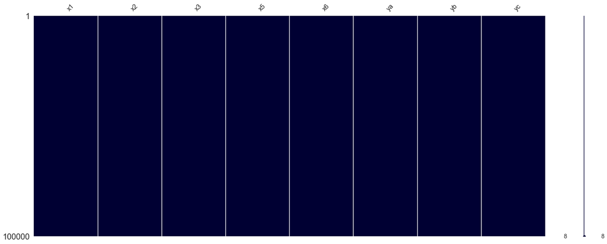

```python
#check for NULLS
msno.matrix(ds1,  color = (.0,.0,.2))
```

### 💭👆🏾This indicates that there are no NULLS.👆🏾💭

Back to Top

### 👇🏾 We now describe the data. 👇🏾¶

- When we talk about describing the data, we look at numerical summaries. These include:
  - the standard deviation to get a sense of the spread of the data
  - the mean and median
  - the min and max
  - the null count
- Pandas has a nice 'describe' method, which we'll use here.
- Next we'll get to the distributions.

```python
ds1.describe()
```

|  | x1 | x2 | x3 | x5 | x6 | ya | yb | yc |
| --- | --- | --- | --- | --- | --- | --- | --- | --- |
| count | 100000.000000 | 100000.000000 | 100000.000000 | 100000.000000 | 100000.000000 | 100000.000000 | 100000.000000 | 1.000000e+05 |
| mean | 5.011059 | -3.005565 | 2.500593 | 0.999136 | 0.000647 | 3.827867 | 2.111854 | 1.022765e-04 |
| std | 2.873568 | 2.000799 | 1.752906 | 1.002006 | 4.663860 | 18.438514 | 0.769306 | 3.121215e-02 |
| min | 0.000015 | -12.498524 | -3.489212 | 0.000003 | -13.885453 | -64.021995 | -0.523672 | -5.433613e-01 |
| 25% | 2.536309 | -4.353844 | 1.189920 | 0.285629 | -2.611943 | -8.998020 | 1.580212 | -2.423158e-03 |
| 50% | 5.022191 | -3.002649 | 2.503764 | 0.690903 | -0.000611 | 2.666992 | 2.231057 | -5.670000e-10 |
| 75% | 7.486275 | -1.649283 | 3.802236 | 1.386862 | 2.621841 | 15.579687 | 2.733318 | 2.476745e-03 |
| max | 9.999887 | 6.089820 | 8.679097 | 15.102966 | 13.924740 | 107.713997 | 3.841363 | 8.183882e-01 |

### 👇🏾 We now will now inspect and fit the distributions. 👇🏾¶

- We will plot histograms to visualize the distributions.
- We will use the Python third party package "fitter" to check these distributions against some of the most common and useful statistical distributions.
  - Fitter was developed by [Thomas Cokelaer](https://github.com/cokelaer)

Back to Top

### 🔬 Function 1: Visualizing & Fitting the Distribution 🔬

- I am about to write a function which will:
  - first, plot a histogram for our five independent and three dependent variables
  - second, use fitter to fit a distribution to our histogram
  - third, just for good measure, add a probability plot
- I will loop it through each column in the data frame to do all this automatically.
- See you on the other side!

```python
def distribution_visualizer_and_fitter(df, col_str):
    #this part makes the histogram:
    fig, axs = plt.subplots(figsize=(12,4))
    plt.hist(df[col_str], bins=100)
    plt.title('Histogram of {}'.format(col_str), fontweight = 'bold')
    plt.ylabel('Frequency')
    plt.xlabel('Values')
    plt.show()
    #this part fits the distribution to the histogram:
    f = Fitter(df[col_str], distributions=['gamma', 'beta', 'rayleigh', 'norm', 'pareto', 'uniform', \
                         'logistic', 'expon', 'chi2', 'pearson3'], verbose = False, timeout = 10)
    f.fit()
    f.summary()
    #this part makes the probability plot
    fig, axs = plt.subplots(ncols=2, figsize=(12,4))
    axs[1].set_axis_off()
    stats.probplot(df[col_str], plot=axs[0])
    plt.show()
```

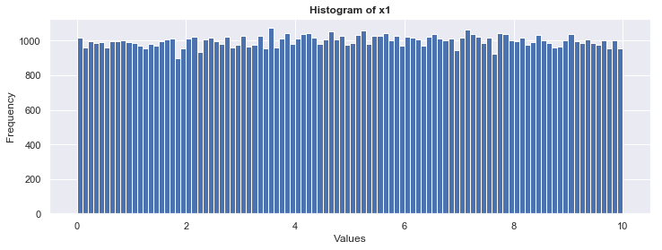

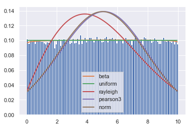

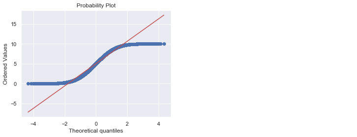

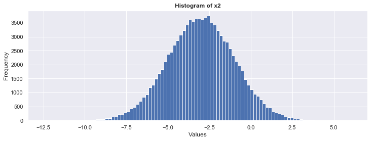

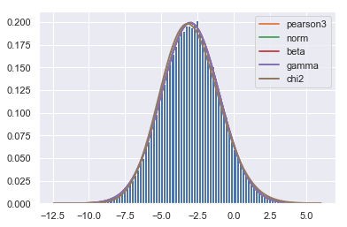

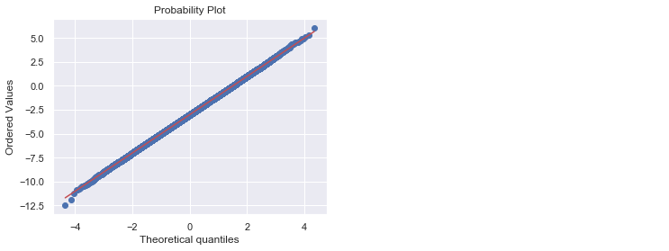

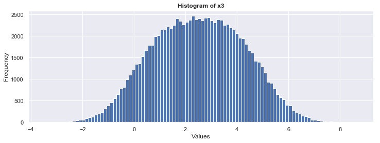

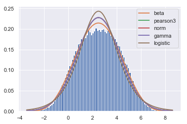

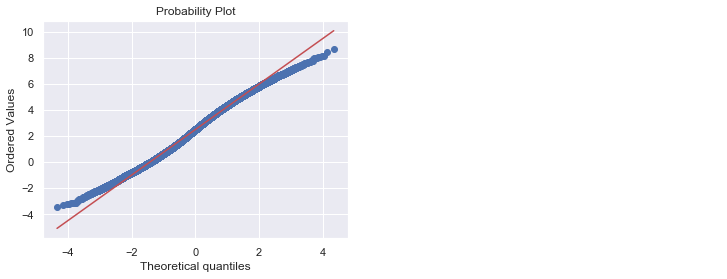

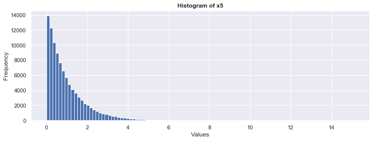

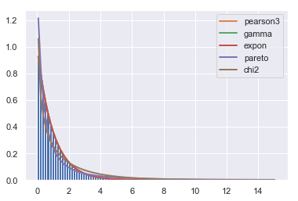

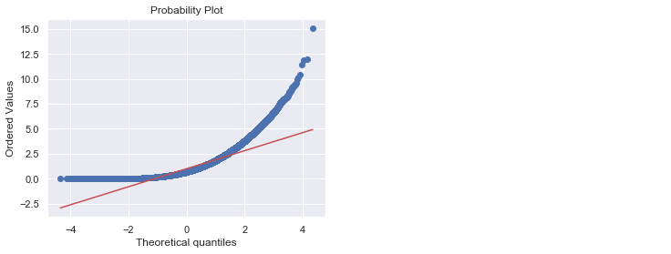

[12 more figures not shown]

```python
for i in ds1.columns:
    distribution_visualizer_and_fitter(ds1, i)
```

Back to Top

### 💭👆🏾Conclusion: What do now know about the distributions?👆🏾💭

- **x1 (independent variable):**
  - *uniform distribution*  
    space
- **x2 (independent variable):**
  - *normal distribution*  
    space
- **x3 (independent variable):**
  - *t-distribution*
    - some will also call this a 'nearly normal' distribution
    - can be modeled with *beta distribution*  
      space
- **x5 (independent variable):**
  - *exponential distribution*
    - a kind of *gamma distribution*  
      space
- **x6 (independent variable):**
  - *binomial distribution*  
    space
- **ya (dependent variable):**
  - *chi2 distribution*
    - can also say it's a positively skewed normal distribution, BUT:
    - to me, the key is the long tail on the right, looks a lot like chi2 distribution  
      space
- **yb (dependent variable):**
  - *reverse log normal distribution*
  - can be approximated with *beta distribution*  
    space
- **yc (dependent variable):**
  - *logistic distribution*
    - more unclear
    - in my subsequent analysis, I'll discuss how I don't think this 'dependent' feature is actually based on the other independent feature
    - however, from my fitting algorithm, it appears a logistic distribution is the closest

Back to Top

## Question 2 - Part I.B

- Try to come up with a predictive model, e.g. y = f(x_1 , … , x_n) for each y sequence. Describe your model and how you came up with them. What (if any) are the predictive variables? How good would you say each of your models is?

Back to Top

## 👇🏾 Modeling Gameplan 👇🏾¶

- First a few assumptions:
  - The problem seems to ask for an equation as the description of the model
  - I assume this means that the client needs a linear regression output
    - Many clients like this because, even if there are more accurate models, a linear regression is highly interpretable
  - Nevertheless, we will still want to begin with a decision tree model because we can use it to figure out which features are most important
    - I will use the decision tree models as a kind of feature selection algorithm
- I will proceed in two steps:
  - **1. Exploratory Data Analysis**
    - Check correlations
    - Check pair plots
    - Check if polynomial transformations or interactions are helpful here
      - I am NOT going to do log transformations because there are too many negative numbers
        - You can add a constant to correct this issue, but you need to really know the underlying data well to do so; and this is something regarding which the Data Scientist should discuss with the team.
        - Why? Because there are some data sets that even though the shift by adding a constant will not alter the variance, it could alter the interpretability or the meaning of the numbers
        - Since we don't know too much about these underlying numbers (as in what they actually represent in real life), I make the decision, for here, not to apply a log transformation
    - To select features I will use:
      - A XGBoost feature importance
      - Backwards elimination regression, if needed
        - Please note that since this is just EDA, there will be no train/test split...I'm just trying to get a sense of what variables 'matter most' across the dataset
      - I will use XGBoost first.
      - This is often my preferred model.
      - However, I'm assuming that the client actually needs an interpretable linear-regression-esque equation
      - Thus we cannot end with XGBoost
        - The nature of the tree splits is to be less interpretable
        - We know that something matters, but we wont' have a coefficient or a direction (positive/negative)
  - **2. Modeling**
    - So after deploying XGBoost for selection, I will run Linear Regressions next for the official modeling
    - This will help us with our ability to understand our features.
      - This regression will **NOT** be scaled.
      - Why?
        - In a word, interpretability
        - Once I scale the data, especially if a normalize it, then I lose the units
        - To be fair, this data does not seem to have units, but I want to make this as real as possible
        - Before we lose the units through scaling and then apply the regularization via Ridge or Lasso, we want to be sure we care more about *prediction* than *inference*
        - Given how this problem is stated, I'm assuming it's an odd combination of 'interpretability prediction', which for here would have to be an interpretable linear regression equation

Back to Top

### 👇🏾 Question 2 - Part I.B - 1. Exploratory Data Analysis 👇🏾¶

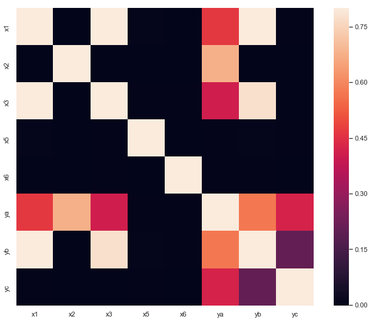

```python
#check correlations
#all credit due to Pedro Marcelino; https://www.kaggle.com/pmarcelino/comprehensive-data-exploration-with-python
corrmat = ds1.corr()
f, ax = plt.subplots(figsize=(12, 9))
sns.heatmap(corrmat, vmax=.8, square=True)
plt.savefig('ds1_correlation_matrix.png',dpi=300, bbox_inches='tight')
```

### 💭👆🏾Just a few thoughts...👆🏾💭

- We can already see that 'dependent' variable 'yc' doesn't seem to be correlated with any of the independent features.
- We also see that the the 'dependent' variables seem to correlate to one another. This may be be because they are somehow generated from the same independent variables.
- This is also going to come up later on, but we can see that x1 and x3 are correlated.
- We can begin to say:
  - **ya** is correlated to x1, x2, and x3
    - this does not factor in colinearity
  - **yb** is correlated to x1 and x3
    - this does not factor in colinearity
  - **yc** does not seem to be correlated to any of the x's

Back to Top

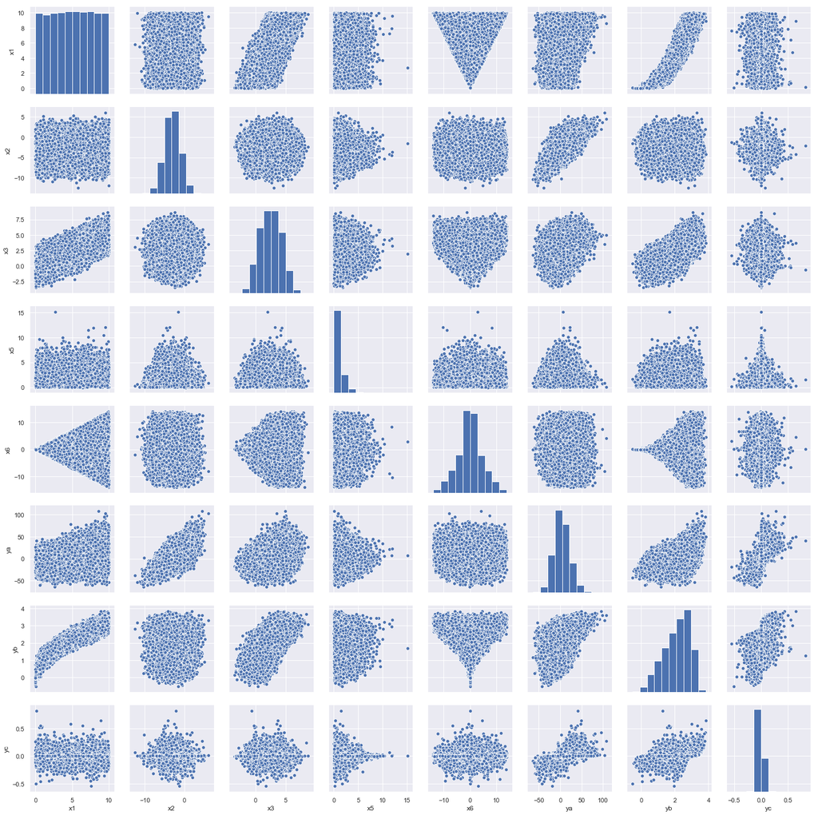

```python
#check the pair plot
#all credit due to Pedro Marcelino; https://www.kaggle.com/pmarcelino/comprehensive-data-exploration-with-python
sns.pairplot(ds1, height = 2.5)
plt.savefig('ds1_pair_plot_lower_res.png',dpi=150, bbox_inches='tight')
plt.show()
```

### 💭👆🏾Just a few thoughts...👆🏾💭

- As we scan the chart, we can see a few linear-ish or nearly linear relationships.
- These charts don't include interactions.
- We see some blobs, and some bizarre relationships.
- We will eliminate features in the feature selection process.

Back to Top

### 👇🏾 Using XGBoost & Regressions To See Which Features Seem Important Before Modeling👇🏾¶

- Now we shall use XGBoost to get an idea for the features that are most important.
- Before checking the polynomial relationships, we just want to get an idea of what's going on.
- After each XGBoost output we'll also put all the features into a regression against the given dependent variable and see how closely the regression follows the XGBoost insights.
- First, we will start by defining our dependent and independent dataframes.

```python
#define the dependent and independent relationships
features = ds1[['x1','x2','x3','x5','x6']]
ya = ds1['ya']
yb = ds1['yb']
yc = ds1['yc']
```

Back to Top

### 🔬 Function 2: XGBoost Modeler 🔬

- This function will check all features against the dependent variables
- It will then plot the predicteds vs. actuals as well as the residuals.
- It will provide pertinent model metrics.
- It will then make a horizontal bar chart for feature importance.

```python
def xgboost_modeler(X, y, cv_folds_int, x_left, x_right, y_bottom, y_top):
    X_train_xgb, X_test, y_train_xgb, y_test = train_test_split\
    (X, y, test_size = 0.2, random_state = 1)
    xgb_model = xgb.XGBRegressor(objective="reg:squarederror", random_state=42)
    xgb_model.fit(X_train_xgb,y_train_xgb)
    y_pred_xgb = xgb_model.predict(X_test)
    #linear regression standard
    #print r^2 and plot linear regression
    print("R^2:"+str(round(r2_score(y_test, y_pred_xgb),4)))
    print("Mean Absolute Error (in original units): "+str(round(mean_absolute_error((y_test),\
                                                                               (y_pred_xgb)),2)))
    print("Median Absolute Error (in original units): "+str(round(median_absolute_error((y_test),\
                                                                               (y_pred_xgb)),2)))
    print("STD of Training Data (in original units): "+str(round(np.std((y_test)),2)))
    print("Mean of Training Data (in original units): "+str(round(np.mean((y_test)),2)))
    print("Residual Skew: "+str(round(stats.skew((y_pred_xgb)-(y_test)),2)))
    print("Residual Kurtosis: "+str(round(stats.kurtosis((y_pred_xgb)-(y_test)),2)))
    fig, axs = plt.subplots(ncols=(3), nrows=(1), figsize=(15,4))
    plt.subplots_adjust(top = 0.95, bottom=0.01, hspace=0.4, wspace=0.16)
    axs[0].scatter((y_test), (y_pred_xgb))
    axs[0].set_title('Actuals (x) vs Predicteds (y)',fontweight = 'bold')
    axs[0].set_xlim([x_left, x_right])
    axs[0].set_ylim([y_bottom, y_top])
    axs[1].scatter((y_test), ((y_pred_xgb)-(y_test)))
    axs[1].set_title('Actuals (x) vs Residuals [pred. - actual] (y)',fontweight = 'bold')
    axs[1].set_xlim([x_left, x_right])
    axs[1].set_ylim([y_bottom, y_top])
    axs[2].hist(((y_pred_xgb)-(y_test)), bins=100)
    axs[2].set_title('Histogram of Residuals [predicted - actual]',fontweight = 'bold')
    plt.savefig('xgboost_modeling_',dpi=300, bbox_inches='tight')
    plt.show()
    print("Cross-Validation Scoring for XGBoost")
    print('Mean Mean Absolute Error: {}'.format(-1*round(cross_val_score(xgb_model, X_train_xgb, y_train_xgb, \
                                                    cv=cv_folds_int, scoring='neg_mean_absolute_error').mean(),2)))
    print('Median Mean Absolute Error: {}'.format(-1*round(np.median(cross_val_score(xgb_model, X_train_xgb,\
                                                                                     y_train_xgb, \
                                                     cv=cv_folds_int, scoring='neg_mean_absolute_error')),2)))
    print('Mean R^2: {}'.format(round(cross_val_score(xgb_model, X_train_xgb, y_train_xgb, cv=cv_folds_int,\
                                                      scoring='r2').mean(),3)))
    print('Median R^2: {}'.format(round(np.median(cross_val_score(xgb_model,\
                                             X_train_xgb, y_train_xgb, cv=cv_folds_int, scoring='r2')),3)))
    print('Max R^2: {}'.format(round(np.max(cross_val_score(xgb_model,\
                                             X_train_xgb, y_train_xgb, cv=cv_folds_int, scoring='r2')),3)))
    print('Min R^2: {}'.format(round(np.min(cross_val_score(xgb_model,\
                                             X_train_xgb, y_train_xgb, cv=cv_folds_int, scoring='r2')),3)))
    top_xgb_features = pd.DataFrame(sorted(list(zip(X,xgb_model.feature_importances_))\
       ,key = lambda x: abs(x[1]),reverse=True)[:10], columns=['Feature', 'XGBoost Importance'])
    top_xgb_features
    bar_count = range(len(top_xgb_features.Feature))
    fig, axs = plt.subplots(ncols=2, figsize=(14,4))
    #using a subplot method coupled with an inline parameter to have high resolution
    #note: "[::-1]" reverses the column in a pandas dataframe
    axs[1].set_axis_off()
    axs[0].barh(bar_count, top_xgb_features['XGBoost Importance'][::-1],\
                 align='center', alpha=1)
    axs[0].set_xlabel('Values')
    axs[0].set_yticks(bar_count)
    axs[0].set_yticklabels(top_xgb_features.Feature[::-1], fontsize=10)
    axs[0].set_xlabel('XGBoost Importance')
    axs[0].set_title("XGBoost's Feature Importances",fontweight = 'bold')
    extent = axs[0].get_window_extent().transformed(fig.dpi_scale_trans.inverted())
    fig.savefig('xgb_features_importance_dependent_var_',dpi=300, bbox_inches=extent.expanded(1.5, 1.5))
    plt.show()
```

Back to Top

### 👇🏾 First, we check dependent variable 'ya'👇🏾¶

```
R^2:0.704
Mean Absolute Error (in original units): 7.99
Median Absolute Error (in original units): 6.79
STD of Training Data (in original units): 18.39
Mean of Training Data (in original units): 3.98
Residual Skew: -0.02
Residual Kurtosis: 0.03
```

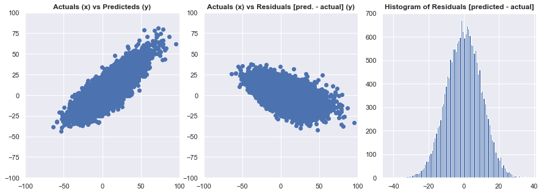

```
Cross-Validation Scoring for XGBoost
Mean Mean Absolute Error: 8.02
Median Mean Absolute Error: 8.03
Mean R^2: 0.703
Median R^2: 0.704
Max R^2: 0.707
Min R^2: 0.696
```

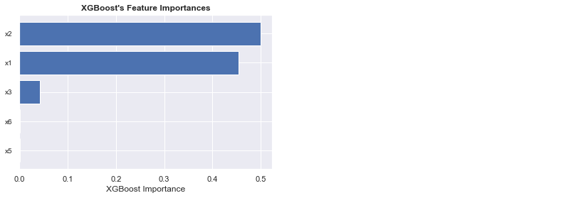

```python
xgboost_modeler(X=features, y=ya, cv_folds_int=4, x_left=-100, x_right=100, y_bottom=-100, y_top=100)
```

### 💭👆🏾Just a few thoughts...👆🏾💭

- This lets us know that for dependent variable **ya** it looks like:
  - x5 and x6 are **not** important
  - x2 is most important, followed by x1 and x3
- We'll also peek at a standard regression...

```python
features_regression = add_constant(features)
regressor_OLS = sm.OLS(endog = ya, exog = features_regression).fit()
regressor_OLS.summary()
```

OLS Regression Results

| Dep. Variable: | ya | R-squared: | 0.677 |
| --- | --- | --- | --- |
| Model: | OLS | Adj. R-squared: | 0.677 |
| Method: | Least Squares | F-statistic: | 4.190e+04 |
| Date: | Mon, 30 Sep 2019 | Prob (F-statistic): | 0.00 |
| Time: | 23:23:39 | Log-Likelihood: | -3.7685e+05 |
| No. Observations: | 100000 | AIC: | 7.537e+05 |
| Df Residuals: | 99994 | BIC: | 7.538e+05 |
| Df Model: | 5 |  |  |
| Covariance Type: | nonrobust |  |  |

|  | coef | std err | t | P>\|t\| | [0.025 | 0.975] |
| --- | --- | --- | --- | --- | --- | --- |
| const | 7.5697 | 0.089 | 84.712 | 0.000 | 7.395 | 7.745 |
| x1 | 2.5177 | 0.020 | 124.571 | 0.000 | 2.478 | 2.557 |
| x2 | 6.2346 | 0.017 | 376.359 | 0.000 | 6.202 | 6.267 |
| x3 | 0.9511 | 0.033 | 28.707 | 0.000 | 0.886 | 1.016 |
| x5 | 0.0023 | 0.033 | 0.070 | 0.944 | -0.063 | 0.067 |
| x6 | 0.0041 | 0.007 | 0.581 | 0.561 | -0.010 | 0.018 |

| Omnibus: | 41.538 | Durbin-Watson: | 1.997 |
| --- | --- | --- | --- |
| Prob(Omnibus): | 0.000 | Jarque-Bera (JB): | 42.505 |
| Skew: | 0.039 | Prob(JB): | 5.89e-10 |
| Kurtosis: | 3.064 | Cond. No. | 19.7 |

Warnings:  
[1] Standard Errors assume that the covariance matrix of the errors is correctly specified.

### 💭👆🏾Just a few thoughts...👆🏾💭

- This regression confirms our XGBoost insights regarding dependent variable **ya**.

Back to Top

### 👇🏾 Second, we check dependent variable 'yb'👇🏾¶

```
R^2:0.9323
Mean Absolute Error (in original units): 0.16
Median Absolute Error (in original units): 0.14
STD of Training Data (in original units): 0.77
Mean of Training Data (in original units): 2.12
Residual Skew: -0.02
Residual Kurtosis: 0.03
```

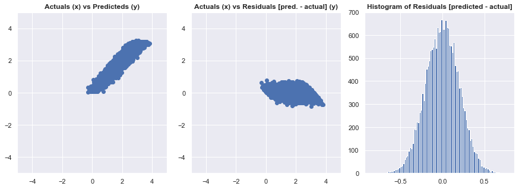

```
Cross-Validation Scoring for XGBoost
Mean Mean Absolute Error: 0.16
Median Mean Absolute Error: 0.16
Mean R^2: 0.932
Median R^2: 0.932
Max R^2: 0.933
Min R^2: 0.931
```

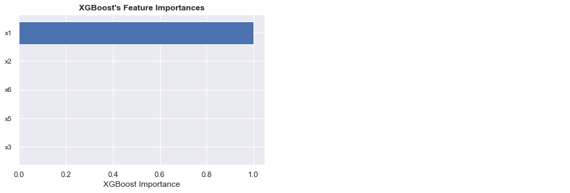

```python
xgboost_modeler(X=features, y=yb, cv_folds_int=4, x_left=-5, x_right=5, y_bottom=-5, y_top=5)
```

### 💭👆🏾Just a few thoughts...👆🏾💭

- This is amazing!!!
- It looks like just *one* variable, **x1** decides what dependent variable **'yb'** is going to be.
- We'll check this with a standard regression...

```python
features_regression = add_constant(features)
regressor_OLS = sm.OLS(endog = yb, exog = features_regression).fit()
regressor_OLS.summary()
```

OLS Regression Results

| Dep. Variable: | yb | R-squared: | 0.895 |
| --- | --- | --- | --- |
| Model: | OLS | Adj. R-squared: | 0.895 |
| Method: | Least Squares | F-statistic: | 1.702e+05 |
| Date: | Mon, 30 Sep 2019 | Prob (F-statistic): | 0.00 |
| Time: | 23:25:20 | Log-Likelihood: | -3038.6 |
| No. Observations: | 100000 | AIC: | 6089. |
| Df Residuals: | 99994 | BIC: | 6146. |
| Df Model: | 5 |  |  |
| Covariance Type: | nonrobust |  |  |

|  | coef | std err | t | P>\|t\| | [0.025 | 0.975] |
| --- | --- | --- | --- | --- | --- | --- |
| const | 0.8427 | 0.002 | 396.244 | 0.000 | 0.839 | 0.847 |
| x1 | 0.2542 | 0.000 | 528.388 | 0.000 | 0.253 | 0.255 |
| x2 | 6.148e-05 | 0.000 | 0.156 | 0.876 | -0.001 | 0.001 |
| x3 | -0.0018 | 0.001 | -2.279 | 0.023 | -0.003 | -0.000 |
| x5 | 0.0003 | 0.001 | 0.353 | 0.724 | -0.001 | 0.002 |
| x6 | 7.677e-05 | 0.000 | 0.454 | 0.650 | -0.000 | 0.000 |

| Omnibus: | 2347.227 | Durbin-Watson: | 1.989 |
| --- | --- | --- | --- |
| Prob(Omnibus): | 0.000 | Jarque-Bera (JB): | 2710.565 |
| Skew: | -0.336 | Prob(JB): | 0.00 |
| Kurtosis: | 3.445 | Cond. No. | 19.7 |

Warnings:  
[1] Standard Errors assume that the covariance matrix of the errors is correctly specified.

### 💭👆🏾Just a few thoughts...👆🏾💭

- Even though you could argue that x3 is also statistically significant, you can see that **x1's** t-score of over 500 shows that it is likely doing most of the work here, just like XGBoost said.
- Let's actually run this regression again...but only for **x1** and see if we keep the R^2 at about the same level (meaning that the variance can be accounted for by **x1**).

### 💭👇🏾Let's also check that one feature, x1, which seems to be doing the brunt of the work here.👇🏾💭

```python
features_regression_x1 = add_constant(ds1.x1)
regressor_OLS = sm.OLS(endog = yb, exog = features_regression_x1).fit()
regressor_OLS.summary()
```

OLS Regression Results

| Dep. Variable: | yb | R-squared: | 0.895 |
| --- | --- | --- | --- |
| Model: | OLS | Adj. R-squared: | 0.895 |
| Method: | Least Squares | F-statistic: | 8.511e+05 |
| Date: | Mon, 30 Sep 2019 | Prob (F-statistic): | 0.00 |
| Time: | 23:25:20 | Log-Likelihood: | -3041.4 |
| No. Observations: | 100000 | AIC: | 6087. |
| Df Residuals: | 99998 | BIC: | 6106. |
| Df Model: | 1 |  |  |
| Covariance Type: | nonrobust |  |  |

|  | coef | std err | t | P>\|t\| | [0.025 | 0.975] |
| --- | --- | --- | --- | --- | --- | --- |
| const | 0.8428 | 0.002 | 531.489 | 0.000 | 0.840 | 0.846 |
| x1 | 0.2533 | 0.000 | 922.571 | 0.000 | 0.253 | 0.254 |

| Omnibus: | 2346.712 | Durbin-Watson: | 1.989 |
| --- | --- | --- | --- |
| Prob(Omnibus): | 0.000 | Jarque-Bera (JB): | 2709.981 |
| Skew: | -0.336 | Prob(JB): | 0.00 |
| Kurtosis: | 3.445 | Cond. No. | 11.9 |

Warnings:  
[1] Standard Errors assume that the covariance matrix of the errors is correctly specified.

### 💭👆🏾Just a few thoughts...👆🏾💭

- Yup, the R^2 didn't budge. It stayed right there at 0.895.
  - Looks like we have the **x1** independent variable predicting the **yb** dependent variable.

Back to Top

### 👇🏾 Third, we check dependent variable 'yc'👇🏾¶

```
R^2:-0.0013
Mean Absolute Error (in original units): 0.01
Median Absolute Error (in original units): 0.0
STD of Training Data (in original units): 0.03
Mean of Training Data (in original units): 0.0
Residual Skew: -0.7
Residual Kurtosis: 43.41
```

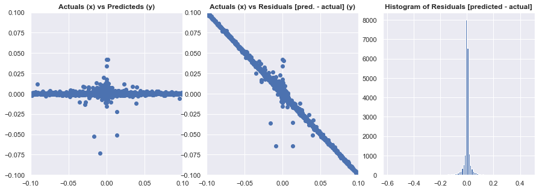

```
Cross-Validation Scoring for XGBoost
Mean Mean Absolute Error: 0.01
Median Mean Absolute Error: 0.01
Mean R^2: -0.003
Median R^2: -0.003
Max R^2: -0.001
Min R^2: -0.006
```

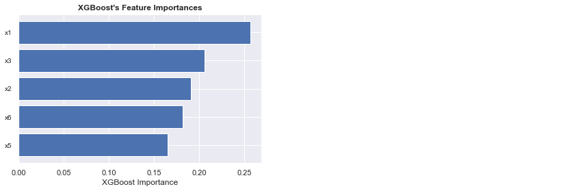

```python
xgboost_modeler(X=features, y=yc, cv_folds_int=4, x_left=-0.1, x_right=0.1, y_bottom=-0.1, y_top=0.1)
```

### 💭👆🏾Just a few thoughts...👆🏾💭

- We know from the correlation chart above that **yc** was going to be trouble because it did not show any correlation to any of the x's.
  - Here we see more of the same. The R^2 in the test case was literally negative. Meaning the model is actually worse than guessing.
  - This is a tell-tale sign that **yc** has **nothing to do** with the x's.
  - We'll double-check this with a regression, and we'll give polynomial feature engineering a shot later on.

Back to Top

```python
features_regression = add_constant(features)
regressor_OLS = sm.OLS(endog = yc, exog = features_regression).fit()
regressor_OLS.summary()
```

OLS Regression Results

| Dep. Variable: | yc | R-squared: | 0.000 |
| --- | --- | --- | --- |
| Model: | OLS | Adj. R-squared: | -0.000 |
| Method: | Least Squares | F-statistic: | 0.9993 |
| Date: | Mon, 30 Sep 2019 | Prob (F-statistic): | 0.416 |
| Time: | 23:26:55 | Log-Likelihood: | 2.0480e+05 |
| No. Observations: | 100000 | AIC: | -4.096e+05 |
| Df Residuals: | 99994 | BIC: | -4.095e+05 |
| Df Model: | 5 |  |  |
| Covariance Type: | nonrobust |  |  |

|  | coef | std err | t | P>\|t\| | [0.025 | 0.975] |
| --- | --- | --- | --- | --- | --- | --- |
| const | -0.0001 | 0.000 | -0.427 | 0.669 | -0.001 | 0.000 |
| x1 | 0.0001 | 6.02e-05 | 2.008 | 0.045 | 2.87e-06 | 0.000 |
| x2 | 7.659e-06 | 4.93e-05 | 0.155 | 0.877 | -8.9e-05 | 0.000 |
| x3 | -0.0002 | 9.87e-05 | -1.844 | 0.065 | -0.000 | 1.14e-05 |
| x5 | 8.846e-05 | 9.85e-05 | 0.898 | 0.369 | -0.000 | 0.000 |
| x6 | -9.798e-07 | 2.12e-05 | -0.046 | 0.963 | -4.25e-05 | 4.05e-05 |

| Omnibus: | 38901.894 | Durbin-Watson: | 1.994 |
| --- | --- | --- | --- |
| Prob(Omnibus): | 0.000 | Jarque-Bera (JB): | 8034394.166 |
| Skew: | 0.721 | Prob(JB): | 0.00 |
| Kurtosis: | 46.888 | Cond. No. | 19.7 |

Warnings:  
[1] Standard Errors assume that the covariance matrix of the errors is correctly specified.

### 💭👆🏾Just a few thoughts...👆🏾💭

- Again, we see an R^2 of 0.
- And p-values don't seem too impressive either. (There are two around the 5% p-value level, but given everything else we've seen, I don't think **yc** relates to the given independent features)
  - ...and if this were Hayward Data Science (my consulting business), I would not model this because we might get an even worse outcome then not knowing -- thinking we know when we are actually wrong.

Back to Top

### 💭👇🏾Brief 'Side Path' - Checking for Polynomial Features👇🏾💭

- We've already discussed that we are not going to perform log transforms due to the negative numbers and the lack of units (such that we don't know if adding a constant will hurt our interpretability even though it wouldn't affect variance.
- What we will want to do is train our XGBoost models on the polynomial features to see if there is marked improvement.
- Just for demonstration purposes I will also run a Backwards Elimination Regression Algorithm as well.

```python
def backwardElimination(X, y, significance_level_float):
    numCols = len(X.columns)
    for i in range(numCols):
        regressor_OLS = sm.OLS(y, X).fit()
        maxVar = max(regressor_OLS.pvalues)
        if maxVar > significance_level_float:
            for j in range(len(regressor_OLS.pvalues)):
                if (regressor_OLS.pvalues[j] == maxVar):
                    X = X.drop(X.columns[j], axis = 1)
    regressor_OLS.summary()
    return X
```

```python
#make the polynomial features
poly = PolynomialFeatures(degree=3, include_bias=False)
features_w_poly = poly.fit_transform(features)
features_w_poly = pd.DataFrame(features_w_poly, columns=poly.get_feature_names(features.columns))
```

```python
#adding in a constant to prepare for regression (we had bias as False above so we need to add the constant now)
features_poly_regression = add_constant(features_w_poly)
```

```
R^2:0.7034
Mean Absolute Error (in original units): 8.0
Median Absolute Error (in original units): 6.78
STD of Training Data (in original units): 18.39
Mean of Training Data (in original units): 3.98
Residual Skew: -0.02
Residual Kurtosis: 0.03
```

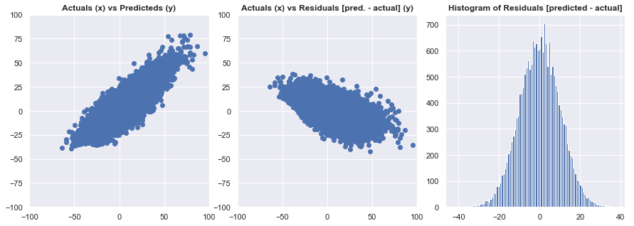

```
Cross-Validation Scoring for XGBoost
Mean Mean Absolute Error: 8.03
Median Mean Absolute Error: 8.03
Mean R^2: 0.703
Median R^2: 0.704
Max R^2: 0.707
Min R^2: 0.697
```

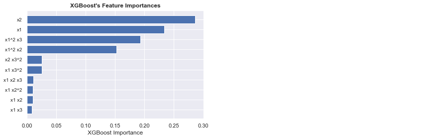

```python
#XGboost polynomial test for ya
xgboost_modeler(X=features_w_poly, y=ya, cv_folds_int=4, x_left=-100, x_right=100, y_bottom=-100, y_top=100)
```

### 💭👆🏾Just a few thoughts...👆🏾💭

- Even with the new polynomial features, we still are focused on x1, and x2.
- Plus the R^2 actually dropped from 0.704 to 0703.
- We've added a ton of features, but we don't see a marked improvement.
- All things being equal, we want a simpler model, so I'll be sticking to the features we had when we move to the modeling stage for **ya**.

Back to Top

```python
#backwards elimination regression algo for ya
#note this cell runs the Backwards Elimination, and this cell will takw a while to execute
Features_Poly_Pruned_ya = backwardElimination(features_poly_regression, ya, significance_level_float = 0.00001)
Features_Poly_Pruned_ya = add_constant(Features_Poly_Pruned_ya)
pruned_regressor_OLS = sm.OLS(endog = ya, exog = Features_Poly_Pruned_ya).fit()
pruned_regressor_OLS.summary()
```

OLS Regression Results

| Dep. Variable: | ya | R-squared: | 0.705 |
| --- | --- | --- | --- |
| Model: | OLS | Adj. R-squared: | 0.705 |
| Method: | Least Squares | F-statistic: | 3.418e+04 |
| Date: | Mon, 30 Sep 2019 | Prob (F-statistic): | 0.00 |
| Time: | 23:41:54 | Log-Likelihood: | -3.7226e+05 |
| No. Observations: | 100000 | AIC: | 7.445e+05 |
| Df Residuals: | 99992 | BIC: | 7.446e+05 |
| Df Model: | 7 |  |  |
| Covariance Type: | nonrobust |  |  |

|  | coef | std err | t | P>\|t\| | [0.025 | 0.975] |
| --- | --- | --- | --- | --- | --- | --- |
| const | 0.6807 | 0.191 | 3.556 | 0.000 | 0.305 | 1.056 |
| x1 | 3.0860 | 0.129 | 23.934 | 0.000 | 2.833 | 3.339 |
| x2 | 3.0625 | 0.048 | 64.086 | 0.000 | 2.969 | 3.156 |
| x3 | 0.9346 | 0.032 | 29.531 | 0.000 | 0.873 | 0.997 |
| x1^2 | 0.2466 | 0.026 | 9.372 | 0.000 | 0.195 | 0.298 |
| x1 x2 | 0.8758 | 0.022 | 39.854 | 0.000 | 0.833 | 0.919 |
| x1^3 | -0.0166 | 0.002 | -9.875 | 0.000 | -0.020 | -0.013 |
| x1^2 x2 | -0.0365 | 0.002 | -17.168 | 0.000 | -0.041 | -0.032 |

| Omnibus: | 3.440 | Durbin-Watson: | 1.993 |
| --- | --- | --- | --- |
| Prob(Omnibus): | 0.179 | Jarque-Bera (JB): | 3.430 |
| Skew: | 0.014 | Prob(JB): | 0.180 |
| Kurtosis: | 3.008 | Cond. No. | 2.87e+03 |

Warnings:  
[1] Standard Errors assume that the covariance matrix of the errors is correctly specified.  
[2] The condition number is large, 2.87e+03. This might indicate that there are  
strong multicollinearity or other numerical problems.

### 💭👆🏾Just a few thoughts...👆🏾💭

- The regression here seems to generally map on to what I just said about the XGBoost run above.
- We added a lot of features, but we don't see much uptick in explanation of variance.
- I'm inclined to stick with my simpler features.

Back to Top

```
R^2:0.9323
Mean Absolute Error (in original units): 0.16
Median Absolute Error (in original units): 0.14
STD of Training Data (in original units): 0.77
Mean of Training Data (in original units): 2.12
Residual Skew: -0.02
Residual Kurtosis: 0.03
```

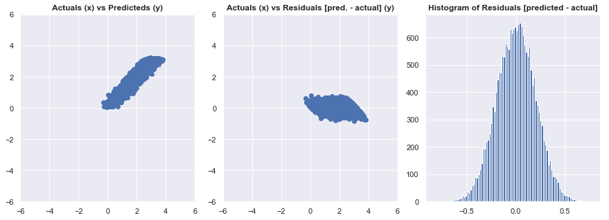

```
Cross-Validation Scoring for XGBoost
Mean Mean Absolute Error: 0.16
Median Mean Absolute Error: 0.16
Mean R^2: 0.932
Median R^2: 0.932
Max R^2: 0.933
Min R^2: 0.931
```

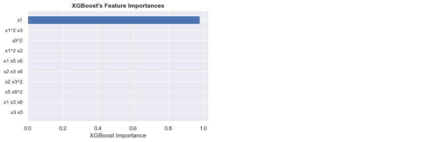

```python
#XGboost polynomial test for yb
xgboost_modeler(X=features_w_poly, y=yb, cv_folds_int=4, x_left=-6, x_right=6, y_bottom=-6, y_top=6)
```

### 💭👆🏾Just a few thoughts...👆🏾💭

- This is truly amazing!!!!!!!!
- No matter what we throw at **yb**, it just wants to stick with x1.
- It's **yb** is the faithful, monogamous type 😊haahahah!

Back to Top

```python
#backwards elimination regression algo for yb
#note this cell runs the Backwards Elimination, and this cell will takw a while to execute
Features_Poly_Pruned_yb = backwardElimination(features_poly_regression, yb, significance_level_float = 0.00001)
Features_Poly_Pruned_yb = add_constant(Features_Poly_Pruned_yb)
pruned_regressor_OLS = sm.OLS(endog = yb, exog = Features_Poly_Pruned_yb).fit()
pruned_regressor_OLS.summary()
```

OLS Regression Results

| Dep. Variable: | yb | R-squared: | 0.930 |
| --- | --- | --- | --- |
| Model: | OLS | Adj. R-squared: | 0.930 |
| Method: | Least Squares | F-statistic: | 4.446e+05 |
| Date: | Mon, 30 Sep 2019 | Prob (F-statistic): | 0.00 |
| Time: | 23:56:28 | Log-Likelihood: | 17486. |
| No. Observations: | 100000 | AIC: | -3.496e+04 |
| Df Residuals: | 99996 | BIC: | -3.493e+04 |
| Df Model: | 3 |  |  |
| Covariance Type: | nonrobust |  |  |

|  | coef | std err | t | P>\|t\| | [0.025 | 0.975] |
| --- | --- | --- | --- | --- | --- | --- |
| const | 0.3990 | 0.003 | 154.586 | 0.000 | 0.394 | 0.404 |
| x1 | 0.6033 | 0.002 | 270.430 | 0.000 | 0.599 | 0.608 |
| x1^2 | -0.0604 | 0.001 | -116.458 | 0.000 | -0.061 | -0.059 |
| x1^3 | 0.0028 | 3.41e-05 | 82.706 | 0.000 | 0.003 | 0.003 |

| Omnibus: | 5.212 | Durbin-Watson: | 1.995 |
| --- | --- | --- | --- |
| Prob(Omnibus): | 0.074 | Jarque-Bera (JB): | 5.344 |
| Skew: | 0.000 | Prob(JB): | 0.0691 |
| Kurtosis: | 3.036 | Cond. No. | 1.97e+03 |

Warnings:  
[1] Standard Errors assume that the covariance matrix of the errors is correctly specified.  
[2] The condition number is large, 1.97e+03. This might indicate that there are  
strong multicollinearity or other numerical problems.

### 💭👆🏾Just a few thoughts...👆🏾💭

- Again, it's all **x1** and variations thereof.
- We're defintiey just going to stick to x1 for the modeling.
  - ❤️ **x1** and **yb** are a true data love story. ❤️

Back to Top

```
R^2:-0.0021
Mean Absolute Error (in original units): 0.01
Median Absolute Error (in original units): 0.0
STD of Training Data (in original units): 0.03
Mean of Training Data (in original units): 0.0
Residual Skew: -0.69
Residual Kurtosis: 43.28
```

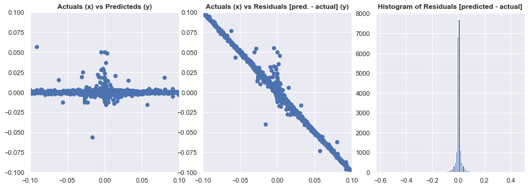

```
Cross-Validation Scoring for XGBoost
Mean Mean Absolute Error: 0.01
Median Mean Absolute Error: 0.01
Mean R^2: -0.004
Median R^2: -0.003
Max R^2: -0.003
Min R^2: -0.007
```

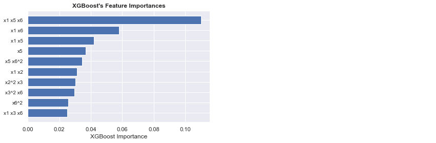

```python
#XGboost polynomial test for yc
xgboost_modeler(X=features_w_poly, y=yc, cv_folds_int=4, x_left=-0.1, x_right=0.1, y_bottom=-0.1, y_top=0.1)
```

### 💭👆🏾Just a few thoughts...👆🏾💭

- Again, it's not looking good for modeling **yc**.
- At first blust it looks like XGBoost may have finally found something, but:
  - We see that we are essentially now interacting x1, x5 and x6 together in one mega column, and we still are only at about 0.10 gain.
  - Since we've seen such limited correlation in our EDA phase, I'm inclined to be quite skeptical here and say that if you throw enough things against the wall, then something is bound to stick.
    - But we are trying to follow the data, not jam the data into our goals.
- I would be inclined to **not** model **yc** at all here.

Back to Top

```python
#backwards elimination regression algo for yc
#note this cell runs the Backwards Elimination, and this cell will takw a while to execute
Features_Poly_Pruned_yc = backwardElimination(features_poly_regression, yc, significance_level_float = 0.00001)
Features_Poly_Pruned_yc = add_constant(Features_Poly_Pruned_yc)
pruned_regressor_OLS = sm.OLS(endog = yc, exog = Features_Poly_Pruned_yc).fit()
pruned_regressor_OLS.summary()
```

OLS Regression Results

| Dep. Variable: | yc | R-squared: | 0.000 |
| --- | --- | --- | --- |
| Model: | OLS | Adj. R-squared: | 0.000 |
| Method: | Least Squares | F-statistic: | inf |
| Date: | Tue, 01 Oct 2019 | Prob (F-statistic): | nan |
| Time: | 00:10:11 | Log-Likelihood: | 2.0480e+05 |
| No. Observations: | 100000 | AIC: | -4.096e+05 |
| Df Residuals: | 99999 | BIC: | -4.096e+05 |
| Df Model: | 0 |  |  |
| Covariance Type: | nonrobust |  |  |

|  | coef | std err | t | P>\|t\| | [0.025 | 0.975] |
| --- | --- | --- | --- | --- | --- | --- |
| const | 0.0001 | 9.87e-05 | 1.036 | 0.300 | -9.12e-05 | 0.000 |

| Omnibus: | 38898.706 | Durbin-Watson: | 1.994 |
| --- | --- | --- | --- |
| Prob(Omnibus): | 0.000 | Jarque-Bera (JB): | 8032981.336 |
| Skew: | 0.720 | Prob(JB): | 0.00 |
| Kurtosis: | 46.884 | Cond. No. | 1.00 |

Warnings:  
[1] Standard Errors assume that the covariance matrix of the errors is correctly specified.

### 💭👆🏾Just a few thoughts...👆🏾💭

- And here we have, as my late Dad would say, 'more trouble in River City.'
  - Namely, in the Backwards Elimination Regression Round none of the independent variables were able to meet the threshold level needed to say in the regression.
  - The data is screaming at us not to model **yc**.

Back to Top

### 👇🏾 Question 2 - Part I.B - 2. Modeling 👇🏾¶

Back to Top

### 🔬 Function 3: Multiple Linear Regression Modeler 🔬

```python
def multiple_linear_regression_modeler(X, y, cv_folds_int, x_left, x_right, y_bottom, y_top):
    X_train1, X_test, y_train1, y_test = train_test_split\
    (X, y, test_size = 0.2, random_state = 1)
    model = LinearRegression()
    model.fit(X_train1,y_train1)
    y_slr_predict = model.predict(X_test)
    #linear regression standard
    #print r^2 and plot linear regression
    print("R^2:"+str(round(r2_score(y_test, y_slr_predict),4)))
    print("Mean Absolute Error (in original units): "+str(round(mean_absolute_error((y_test),\
                                                                               (y_slr_predict)),2)))
    print("STD of Training Data (in original units): "+str(round(np.std((y_test)),2)))
    print("Mean of Training Data (in original units): "+str(round(np.mean((y_test)),2)))
    print("Residual Skew: "+str(round(stats.skew((y_slr_predict)-(y_test)),2)))
    print("Residual Kurtosis: "+str(round(stats.kurtosis((y_slr_predict)-(y_test)),2)))
    fig, axs = plt.subplots(ncols=(3), nrows=(1), figsize=(15,4))
    plt.subplots_adjust(top = 0.95, bottom=0.01, hspace=0.25, wspace=0.16)
    axs[0].scatter((y_test), (y_slr_predict))
    axs[0].set_title('Actuals (x) vs Predicteds (y)',fontweight = 'bold')
    axs[0].set_xlim([x_left, x_right])
    axs[0].set_ylim([y_bottom, y_top])
    axs[1].scatter((y_test), ((y_slr_predict)-(y_test)))
    axs[1].set_title('Actuals (x) vs Residuals [pred. - actual] (y)',fontweight = 'bold')
    axs[1].set_xlim([x_left, x_right])
    axs[1].set_ylim([y_bottom, y_top])
    axs[2].hist(((y_slr_predict)-(y_test)), bins=100)
    axs[2].set_title('Histogram of Residuals [predicted - actual]',fontweight = 'bold')
    plt.savefig('linear_regression_modeling_',dpi=300, bbox_inches='tight')
    plt.show()
    print("Cross-Validation Scoring for Standard Linear Regression")
    print('Mean Absolute Error: {}'.format(-1*round(cross_val_score(model, X_train1, y_train1, \
                                                 cv=cv_folds_int, scoring='neg_mean_absolute_error').mean(),2)))
    print('Median Mean Absolute Error: {}'.format(-1*round(np.median(cross_val_score(model, X_train1, y_train1, \
                                                 cv=cv_folds_int, scoring='neg_mean_absolute_error')),2)))

    print('Mean R^2: {}'.format(round(cross_val_score(model, X_train1, y_train1, cv=cv_folds_int, \
                                                 scoring='r2').mean(),2)))
    print('Median R^2: {}'.format(round(np.median(cross_val_score(model,\
                                             X_train1, y_train1, cv=cv_folds_int, scoring='r2')),3)))
    print('Max R^2: {}'.format(round(np.max(cross_val_score(model,\
                                             X_train1, y_train1, cv=cv_folds_int, scoring='r2')),3)))
    print('Min R^2: {}'.format(round(np.min(cross_val_score(model,\
                                             X_train1, y_train1, cv=cv_folds_int, scoring='r2')),3)))
    linear_regression_feature_list = []
    linear_regression_coef_list = []
    for i in X.columns:
        linear_regression_feature_list.append(i)
    for i in range(len(model.coef_)):
        linear_regression_coef_list.append(model.coef_[i])
    top_10_linear_regression_features = pd.DataFrame(sorted(list(zip(linear_regression_feature_list,\
                                                                     linear_regression_coef_list))\
       ,key = lambda x: abs(x[1]),reverse=True)[:10], columns=['Feature', 'Linear Regression Coefficient'])
    top_10_linear_regression_features
    print(top_10_linear_regression_features)
    print('Intercept: {}'.format(model.intercept_))
```

Back to Top

### 🔬 Function 4: Single Linear Regression Modeler 🔬

```python
def single_linear_regression_modeler(X, single_feature_str, y, cv_folds_int, x_left, x_right, y_bottom, y_top):
    X_train1, X_test, y_train1, y_test = train_test_split(X, y, test_size = 0.2, random_state = 1)
    model = LinearRegression()
    model.fit(X_train1,y_train1)
    y_slr_predict = model.predict(X_test)
    print("R^2:"+str(round(r2_score(y_test, y_slr_predict),4)))
    print("Mean Absolute Error (in original units): "+str(round(mean_absolute_error((y_test),\
                                                                                   (y_slr_predict)),2)))
    print("STD of Training Data (in original units): "+str(round(np.std((y_test)),2)))
    print("Mean of Training Data (in original units): "+str(round(np.mean((y_test)),2)))
    print("Residual Skew: "+str(round(stats.skew((y_slr_predict)-(y_test)),2)))
    print("Residual Kurtosis: "+str(round(stats.kurtosis((y_slr_predict)-(y_test)),2)))
    fig, axs = plt.subplots(ncols=(3), nrows=(1), figsize=(15,4))
    plt.subplots_adjust(top = 0.95, bottom=0.01, hspace=0.25, wspace=0.16)
    axs[0].scatter((y_test), (y_slr_predict))
    axs[0].set_title('Actuals (x) vs Predicteds (y)',fontweight = 'bold')
    axs[0].set_xlim([x_left, x_right])
    axs[0].set_ylim([y_bottom, y_top])
    axs[1].scatter((y_test), ((y_slr_predict)-(y_test)))
    axs[1].set_title('Actuals (x) vs Residuals [pred. - actual] (y)',fontweight = 'bold')
    axs[1].set_xlim([x_left, x_right])
    axs[1].set_ylim([y_bottom, y_top])
    axs[2].hist(((y_slr_predict)-(y_test)), bins=100)
    axs[2].set_title('Histogram of Residuals [predicted - actual]',fontweight = 'bold')
    plt.savefig('linear_regression_modeling_',dpi=300, bbox_inches='tight')
    plt.show()
    print("Cross-Validation Scoring for Standard Linear Regression")
    print('Mean Absolute Error: {}'.format(-1*round(cross_val_score(model, X_train1, y_train1, \
                                                     cv=cv_folds_int, scoring='neg_mean_absolute_error').mean(),2)))
    print('Median Mean Absolute Error: {}'.format(-1*round(np.median(cross_val_score(model, X_train1, y_train1, \
                                                     cv=cv_folds_int, scoring='neg_mean_absolute_error')),2)))

    print('Mean R^2: {}'.format(round(cross_val_score(model, X_train1, y_train1, cv=cv_folds_int, \
                                                     scoring='r2').mean(),2)))
    print('Median R^2: {}'.format(round(np.median(cross_val_score(model,\
                                                 X_train1, y_train1, cv=cv_folds_int, scoring='r2')),3)))
    print('Max R^2: {}'.format(round(np.max(cross_val_score(model,\
                                                 X_train1, y_train1, cv=cv_folds_int, scoring='r2')),3)))
    print('Min R^2: {}'.format(round(np.min(cross_val_score(model,\
                                                 X_train1, y_train1, cv=cv_folds_int, scoring='r2')),3)))
    linear_regression_feature_list = []
    linear_regression_coef_list = []
    for i in list([single_feature_str]):
        linear_regression_feature_list.append(i)
    for i in range(len(model.coef_)):
        linear_regression_coef_list.append(model.coef_[i])
        top_10_linear_regression_features = pd.DataFrame(sorted(list(zip(linear_regression_feature_list,\
                                                                         linear_regression_coef_list))\
           ,key = lambda x: abs(x[1]),reverse=True)[:10], columns=['Feature', 'Linear Regression Coefficient'])
    top_10_linear_regression_features
    print(top_10_linear_regression_features)
    print('Intercept: {}'.format(model.intercept_))
```

### 👇🏾 First, let's build a multiple linear regression model for dependent variable 'ya.'👇🏾

```
R^2:0.6769
Mean Absolute Error (in original units): 8.33
STD of Training Data (in original units): 18.39
Mean of Training Data (in original units): 3.98
Residual Skew: -0.04
Residual Kurtosis: 0.1
```

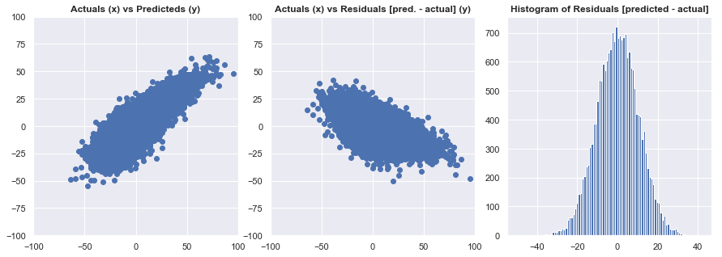

```
Cross-Validation Scoring for Standard Linear Regression
Mean Absolute Error: 8.36
Median Mean Absolute Error: 8.36
Mean R^2: 0.68
Median R^2: 0.677
Max R^2: 0.683
Min R^2: 0.671
  Feature  Linear Regression Coefficient
0      x2                       6.236009
1      x1                       2.513063
2      x3                       0.956032
Intercept: 7.579525599825636
```

```python
multiple_linear_regression_modeler(X=ds1[['x1','x2','x3']],
                        y=ya, cv_folds_int=4, x_left=-100, x_right=100, y_bottom=-100,y_top=100)
```

Back to Top

### 👇🏾 Second, let's build a single linear regression model for dependent variable 'yb.'👇🏾¶

```
R^2:0.8965
Mean Absolute Error (in original units): 0.2
STD of Training Data (in original units): 0.77
Mean of Training Data (in original units): 2.12
Residual Skew: 0.32
Residual Kurtosis: 0.38
```

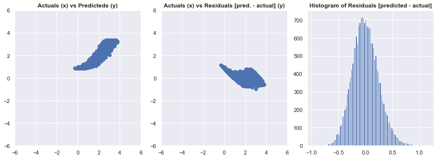

```
Cross-Validation Scoring for Standard Linear Regression
Mean Absolute Error: 0.2
Median Mean Absolute Error: 0.2
Mean R^2: 0.89
Median R^2: 0.894
Max R^2: 0.895
Min R^2: 0.894
  Feature  Linear Regression Coefficient
0      x1                        0.25334
Intercept: 0.8422290091647144
```

```python
single_linear_regression_modeler(X=ds1.x1.values.reshape(-1, 1), single_feature_str='x1',\
                                 y=yb, cv_folds_int=4, x_left=-6, x_right=6, y_bottom=-6, y_top=6)
```

Back to Top

## 👇🏾 Conclusion: Equation for Predicting 'yb.' 👇🏾

$ \begin{align} yb = 0.253(x1) + 0.8422 \end{align} $

```
R^2:1.0
Mean Absolute Error (in original units): 0.0
STD of Training Data (in original units): 0.03
Mean of Training Data (in original units): 0.0
Residual Skew: -1.59
Residual Kurtosis: 3.56
```

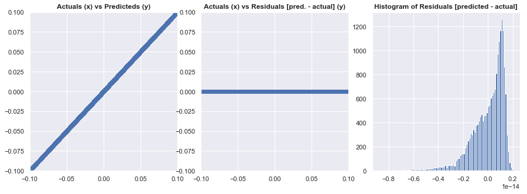

```
Cross-Validation Scoring for Standard Linear Regression
Mean Absolute Error: 0.0
Median Mean Absolute Error: 0.0
Mean R^2: 1.0
Median R^2: 1.0
Max R^2: 1.0
Min R^2: 1.0
  Feature  Linear Regression Coefficient
0      yc                   1.000000e+00
1      yb                   7.799962e-15
2      x1                  -1.658834e-15
3      x2                   8.528791e-16
4      x3                   1.688990e-16
5      ya                  -1.358584e-16
6      x5                  -2.225314e-17
7      x6                  -2.418898e-18
Intercept: -5.4766033288217164e-15
```

```python
multiple_linear_regression_modeler(X=ds1,y=yc, cv_folds_int=4, x_left=-0.1, x_right=0.1, y_bottom=-0.1, y_top=0.1)
```

Back to Top

## 👇🏾 Conclusion: No Equation for Predicting 'yc.' 👇🏾

Back to Top

# Part II. - Unsupervised Machine Learning

- Consider data set 2 (ds2.csv). The data asset comprises a set of observations.

Back to Top

## Question 3 - Part II.A

- Describe the data set in a few sentences.

### 👇🏾 Just as we did in Part 1, Question 1, we begin by reading in the data. 👇🏾

- We will check for NULLS.
- For some reason there is an index column in the raw data, but a Pandas dataframe comes with an index column by default so we will drop this 'extra' index column in the raw data.
- We will summarize the data.
- We will also check the distributions.

```python
ds2 = pd.read_csv('ds2.csv')
```

```python
#drop the extra index column since a Pandas dataframe has one built in
ds2 = ds2.drop(ds2.columns[0], axis=1)
```

```python
#peek at the data
ds2.head()
```

|  | X1 | X2 | X3 | X4 | X5 | X6 | X7 | X8 | X9 | X10 |
| --- | --- | --- | --- | --- | --- | --- | --- | --- | --- | --- |
| 0 | 23.778224 | 13.319974 | 15.565124 | -3.713626 | 7.296793 | -19.371013 | -0.894130 | -6.110282 | -28.959316 | 2.851336 |
| 1 | 16.602950 | 23.311281 | 21.099052 | -0.304154 | -3.218990 | 2.357643 | 12.027277 | 7.070349 | -5.762185 | -23.050198 |
| 2 | 12.084683 | 19.710443 | 9.837102 | -1.081918 | -1.201942 | 9.738019 | 16.125920 | 19.119391 | -15.582122 | -12.292535 |
| 3 | 13.044534 | 10.749040 | 5.884407 | -11.703525 | -4.134358 | -22.344666 | -1.263349 | 0.493711 | -15.305347 | 6.799087 |
| 4 | 8.314115 | 6.748794 | 5.388535 | -0.000290 | -4.724787 | -16.346812 | 3.293600 | -10.848273 | -17.285491 | 6.034214 |

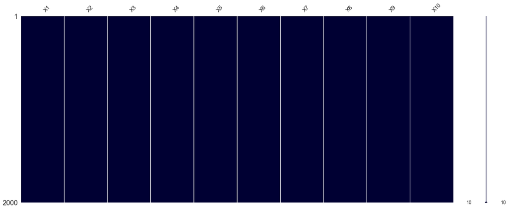

```python
#check for NULLS
msno.matrix(ds2,  color = (.0,.0,.2))
```